# Local Metabolism Plots

```r
# set the root to the project directory, not the rmd directory
knitr::opts_knit$set(root.dir = rprojroot::find_rstudio_root_file())
# default to not printing the code
knitr::opts_chunk$set(echo = FALSE)

# libraries
library(tidyverse)
library(sf)
library(stars)
library(tmap)
library(transformr) # not needed for this doc at present?
library(gganimate) # not needed here at present
library(viridis)
library(colorspace)
```

Purpose here is primarily to go through some plots, look at them, and make static versions for the paper. This is mostly a copy-paste and translate over from metabolismLocalAndStatic. I’ve done this to split out the data read-in, function definitions, and plotting (and particularly the plot trying-out). I’ve been using these notebooks for plot testing, because it’s really nice to be able to scroll around and see what we’ve done, rather than have to keep re-making plot objects when we forget what they look like.

*The catch with this approach is the quick and dirty prototyping isn’t quite so quick, and this document ends up taking FOREVER to load.* Might switch back? But it sure is nice to actually see what each figure I made looks like, especially when we’re likely to drop this for extended periods.

Set the date for examples

## Static versions with drivers and outcomes

Make a static version using the tmap functions

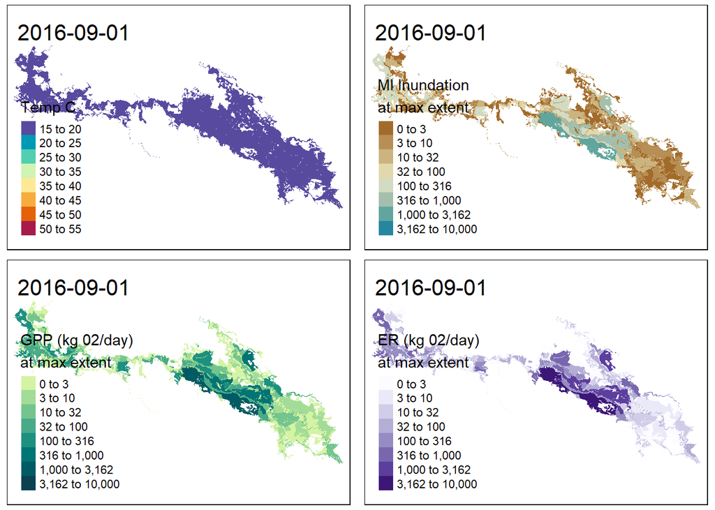

Clean that up just a bit, with a grey background. probably pull the title off but it’s nice to have as reference while i’m making these

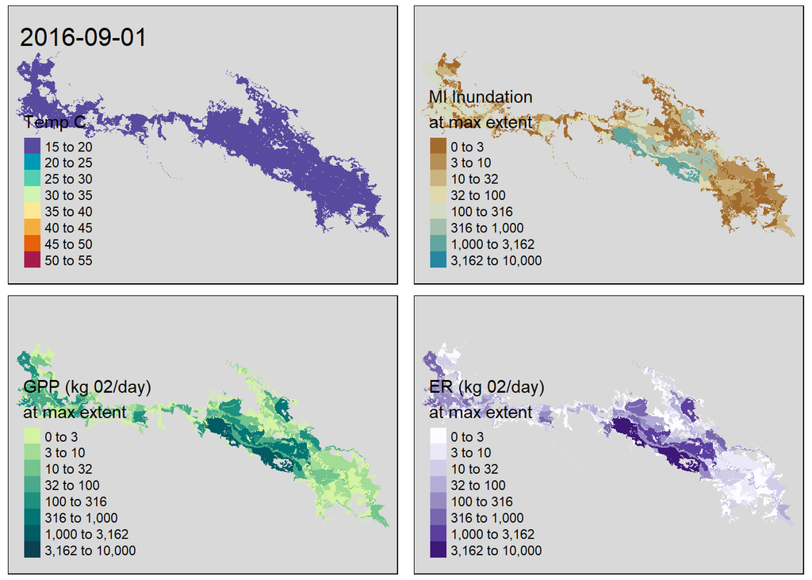

I think for completeness let’s make a ggplot version too and see which is better. Takes more work, but have more control (probably just because I speak ggplot)

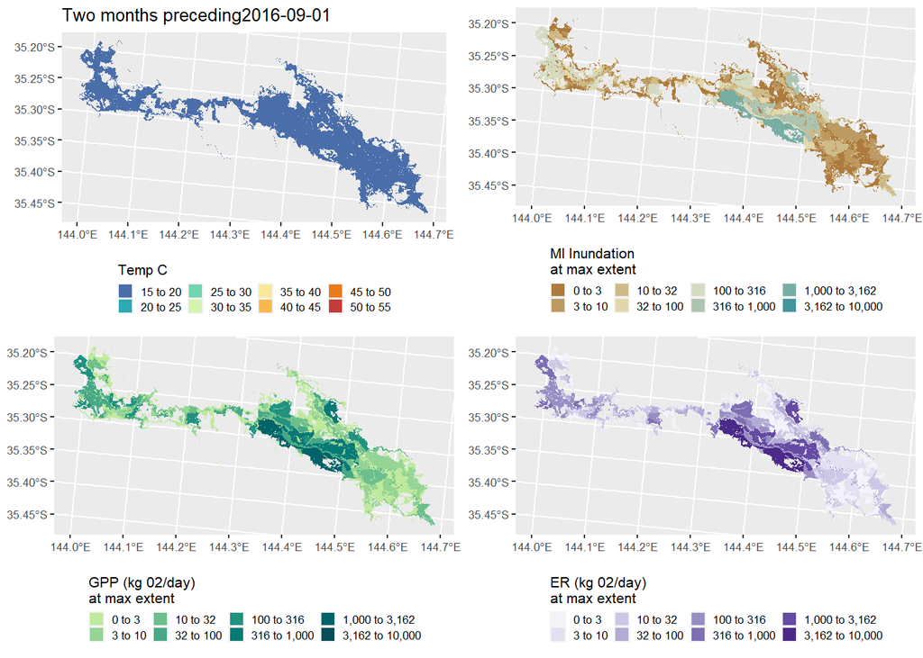

Code block to print and make those into figs

## Uncertainty

I think now that I have the functions, there’s a slicker way to do this, but I don’t want to reinvent the wheel at this point. Might want to turn this into a function?

ER

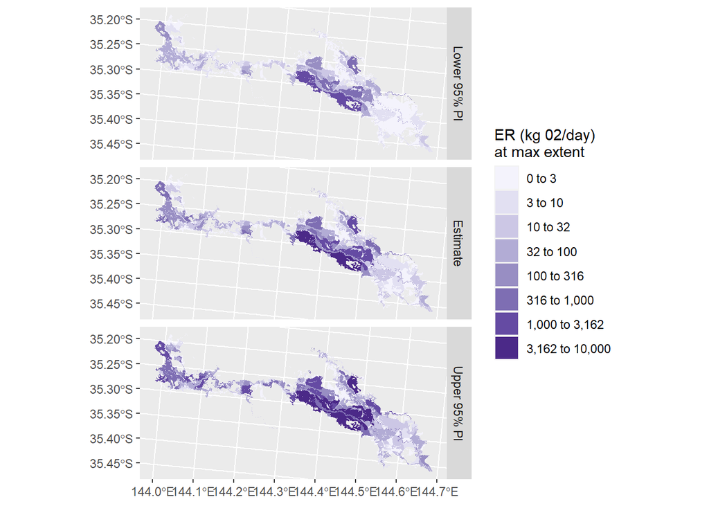

GPP

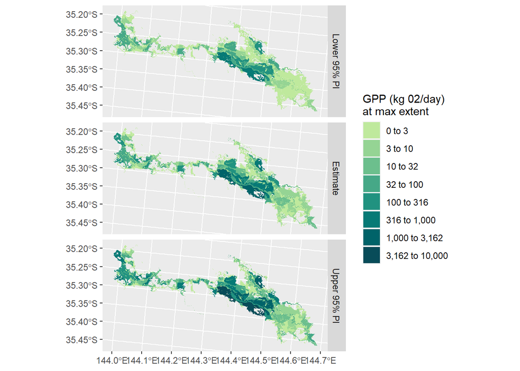

Combine the ER and GPP and save as figures

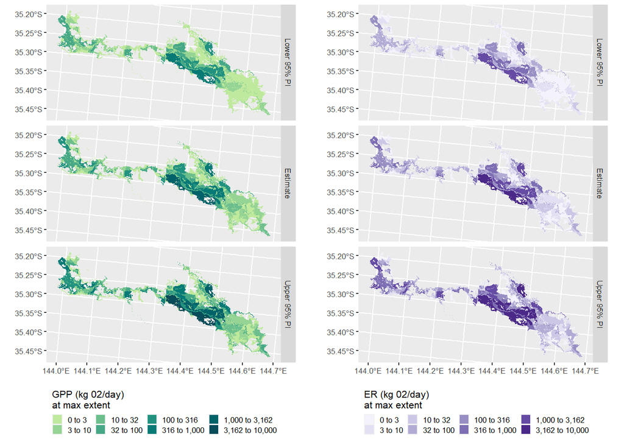

## Bar charts

make a wide version of the data so I can have mins and maxes OR, should I do all of them and fct_order them?

Joining seems safe, but geographic joins are a mess. It doesn’t work at all. binding cols is actually safer and works

### GPP

Maybe for a subset of wetlands?

```
## [1] 3
```

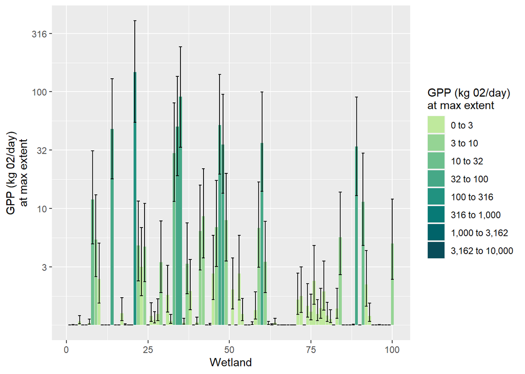

I assume it is a mes to just throw them all on actually, with a fair amount of monkeying with the look, that’s OK

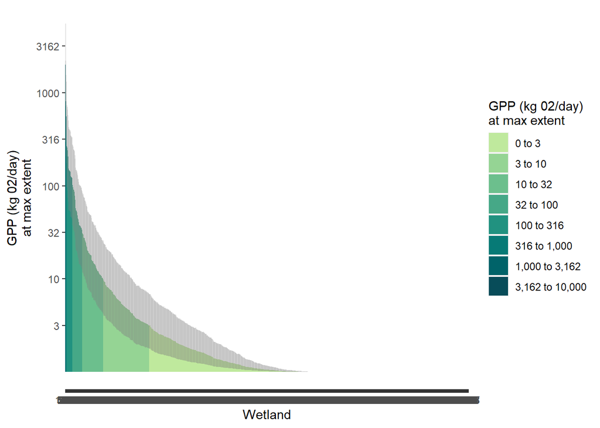

I actually like that that encompasses an area that integrates to total production across the Werai

I can do points as below, but the integration implied above is nice

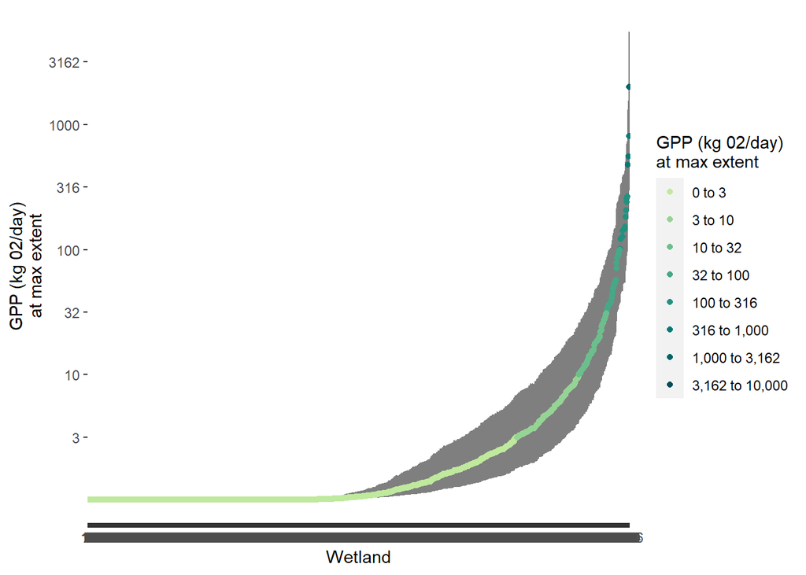

### ER

Setup block. Again, this could be sorted with a function, but right now just copy-pasting

Barplot

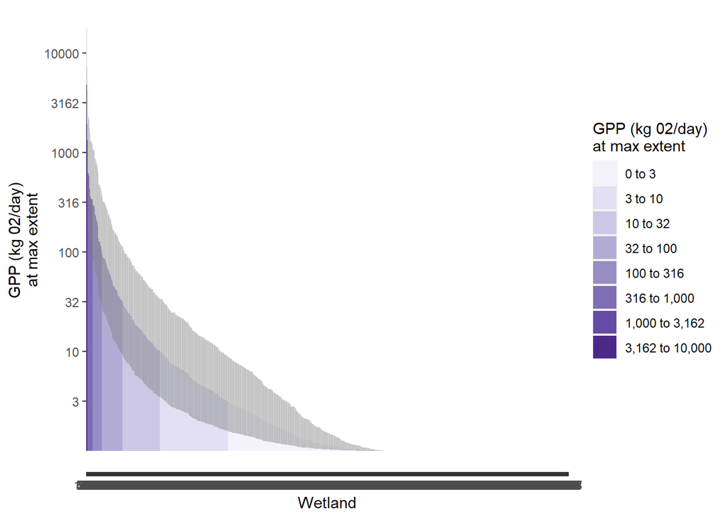

### Both together, with GPP up and ER down

Setup

Try a plot

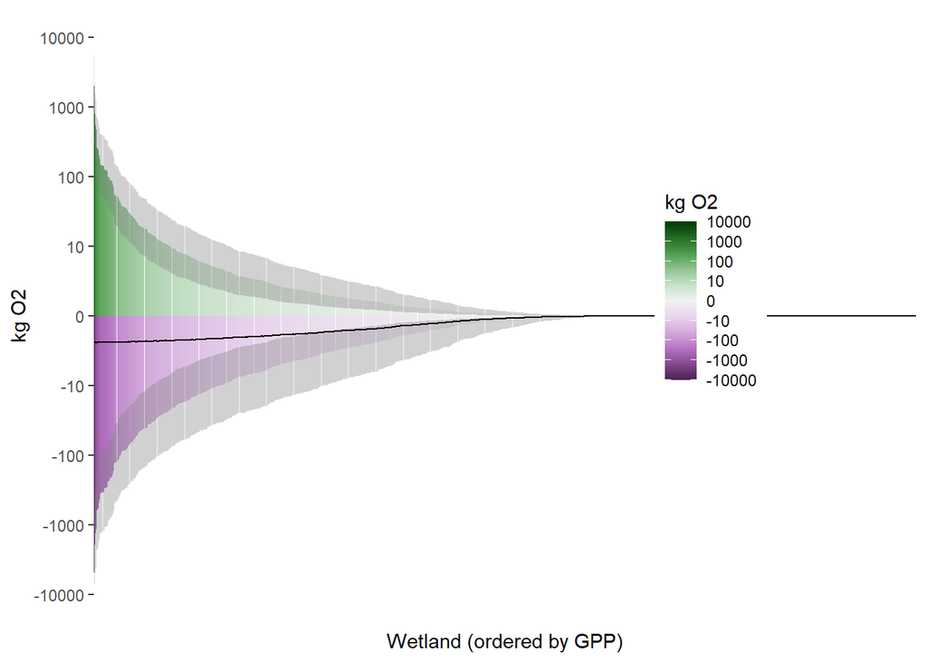

The inability to label x in a reasonable way is infuriating. Can I do it differently? Try making a labelled dataset that’s arranged how I was doing fct_reorder.

Make the plot. Interesting that the notebook plotter does a worse job than the plots panel for a script. The funny gaps aren’t really there- to see, run barboth in the console.

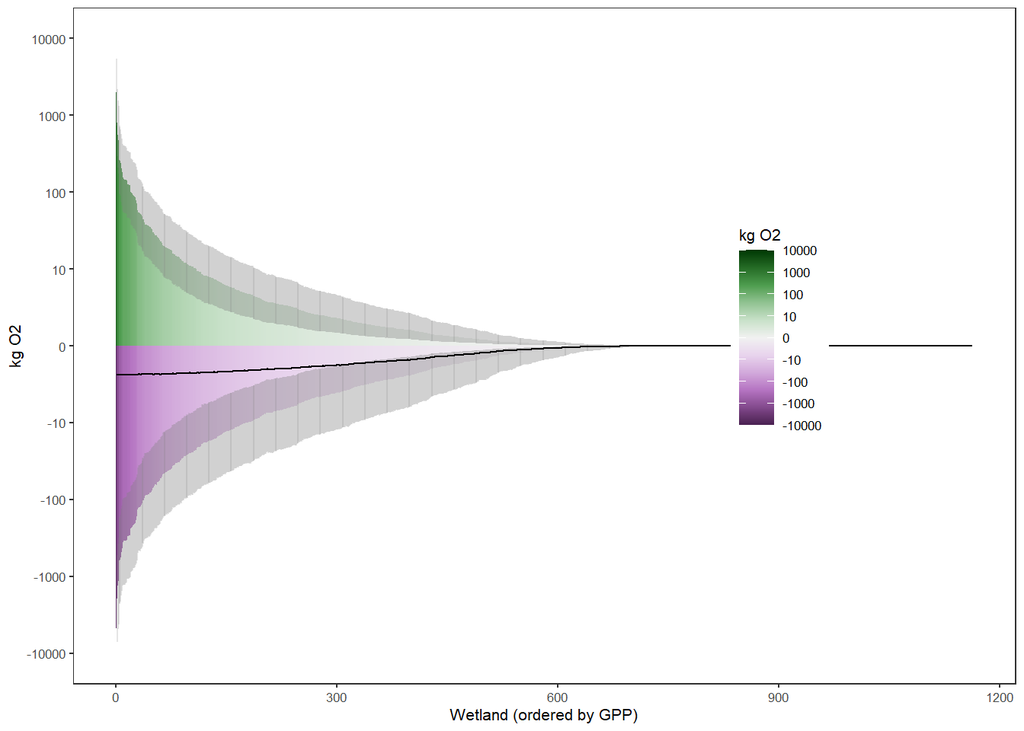

Save that as a figure

What about Darren’s fingerprints? They would maybe take the GPP and ER and make a density with them? OUt of what? The wetlands? Could work. Would need to sort out the weighting by volume. it’s already in there, but that means it will give each location the same weight. I think a better thing for the fingerprints would be to remove it, and then give each wetland its predicted per liter rate and weight by volume IE use the straight predictions and then weight by inundaton Should be straightforward, but likely won’t be

Would be a really cool way to look at scenarios. especially if I can do it for whole catchments

BUT, because GPP and ER are both linear fits of temp, they will exactly predict each other according to a linear relationship, and so there won’t be any 2-d variation and all the points will fall on a line. IE for a given GPP there will only be one ER, and so the fingerprint will be a line. Cool idea, but we’d need more info about their variance relative to each other

## Annual reporting

What about making some examples to illustrate annual (or arbitrary time period) reporting?

First, establish the time periods and do the aggregations and other data organisation

|  | geometry | WaterYear | GPP | logGPP |
| --- | --- | --- | --- | --- |
| 1 |  | 2014-06-29 | 0.000000e+00 | 0.000000e+00 |
| 2 |  | 2015-06-29 | 0.000000e+00 | 0.000000e+00 |
| 3 |  | 2016-06-29 | 2.518394e-01 | 9.754861e-02 |
| 4 |  | 2017-06-29 | 0.000000e+00 | 0.000000e+00 |
| 5 |  | 2018-06-29 | 0.000000e+00 | 0.000000e+00 |
| 6 |  | 2014-06-29 | 0.000000e+00 | 0.000000e+00 |
| 7 |  | 2015-06-29 | 0.000000e+00 | 0.000000e+00 |
| 8 |  | 2016-06-29 | 9.592126e-01 | 2.920816e-01 |
| 9 |  | 2017-06-29 | 4.401779e-02 | 1.870790e-02 |
| 10 |  | 2018-06-29 | 0.000000e+00 | 0.000000e+00 |

[output cut: 5805 more lines]

```
## [1] 3.412777
```

```
## [1] 0.0 0.5 1.0 1.5 2.0 2.5 3.0 3.5 4.0
```

|  | geometry | WaterYear | ER | logER |
| --- | --- | --- | --- | --- |
| 1 |  | 2014-06-29 | 0.000000e+00 | 0.000000e+00 |
| 2 |  | 2015-06-29 | 0.000000e+00 | 0.000000e+00 |
| 3 |  | 2016-06-29 | 5.288478e-01 | 1.843642e-01 |
| 4 |  | 2017-06-29 | 0.000000e+00 | 0.000000e+00 |
| 5 |  | 2018-06-29 | 0.000000e+00 | 0.000000e+00 |
| 6 |  | 2014-06-29 | 0.000000e+00 | 0.000000e+00 |
| 7 |  | 2015-06-29 | 0.000000e+00 | 0.000000e+00 |
| 8 |  | 2016-06-29 | 2.017796e+00 | 4.796899e-01 |
| 9 |  | 2017-06-29 | 9.518690e-02 | 3.948824e-02 |
| 10 |  | 2018-06-29 | 0.000000e+00 | 0.000000e+00 |

[output cut: 5805 more lines]

```
## [1] 3.779558
```

```
## [1] 0.0 0.5 1.0 1.5 2.0 2.5 3.0 3.5 4.0
```

I don’t think I use this, but I did make a full-werai aggregation

### Tmap Plots

Make a facetted tmap

Again, can I do this by modifying what I pass to the plotting functions? Almost certainly

The units are weird, because this is added up across bimonths. It’s neither the total or the average.Not really sure what to call it

Change the tmap_mode() depending on the purpose. DO NOT CHANGE TO VIEW AND TRY TO RUN HERE. IF YOU WANT TO VIEW, CHANGE AND RUN IN CONSOLE. The markdown will run it, but incredibly slowly.

GPP

```
## tmap mode set to plotting
```

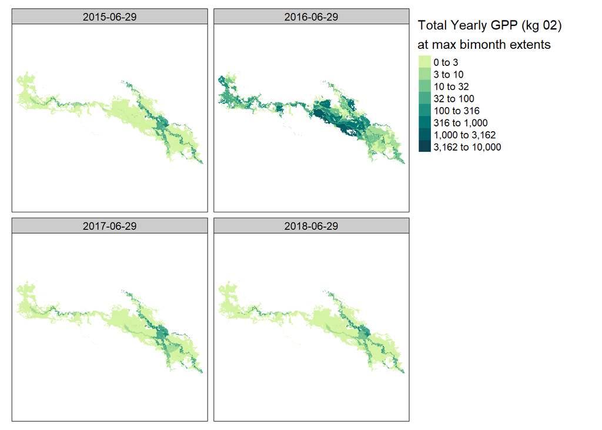

ER

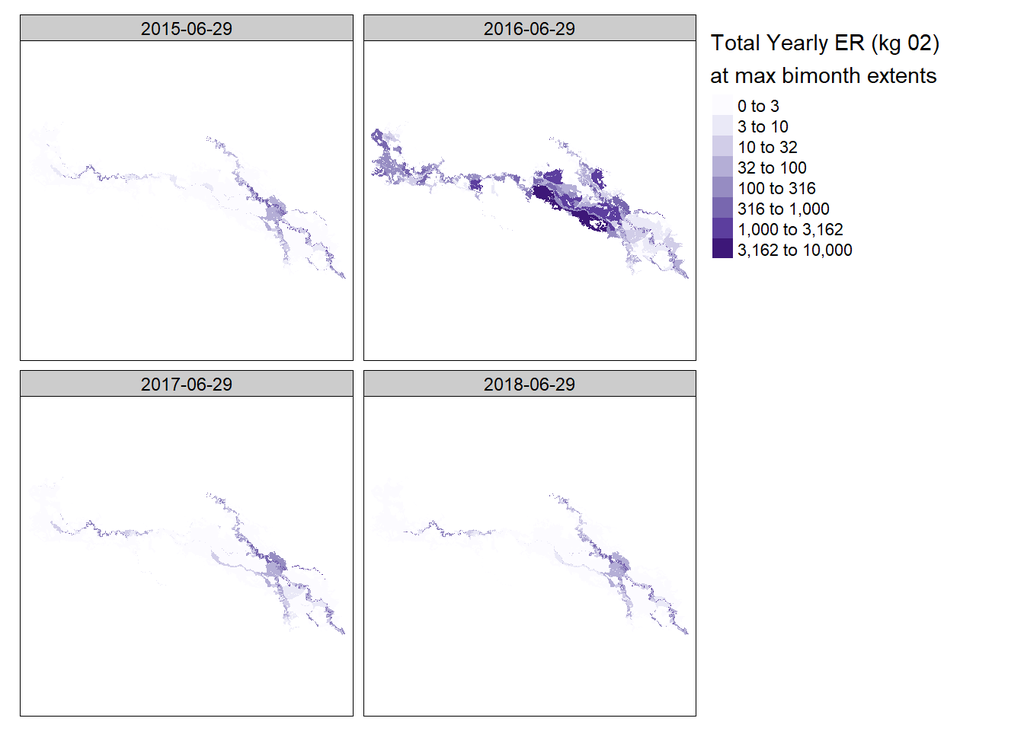

### GGPLOT

gpp

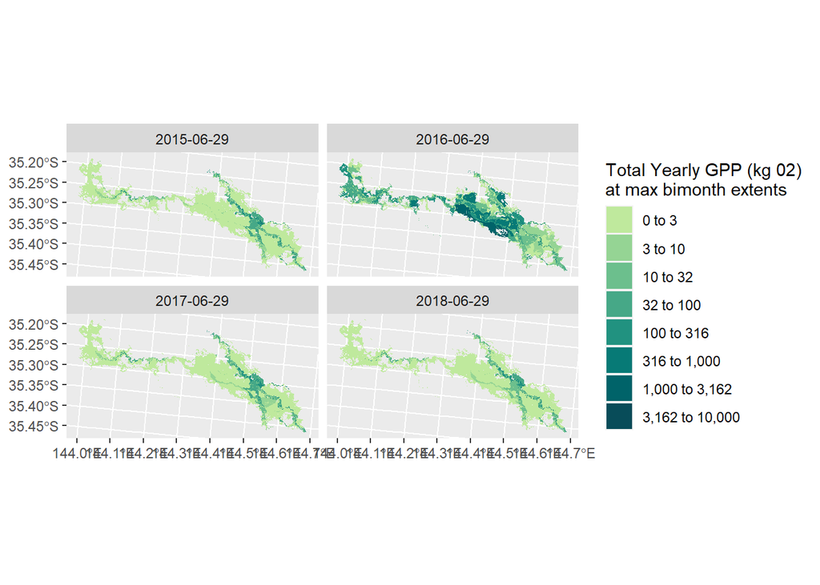

ER

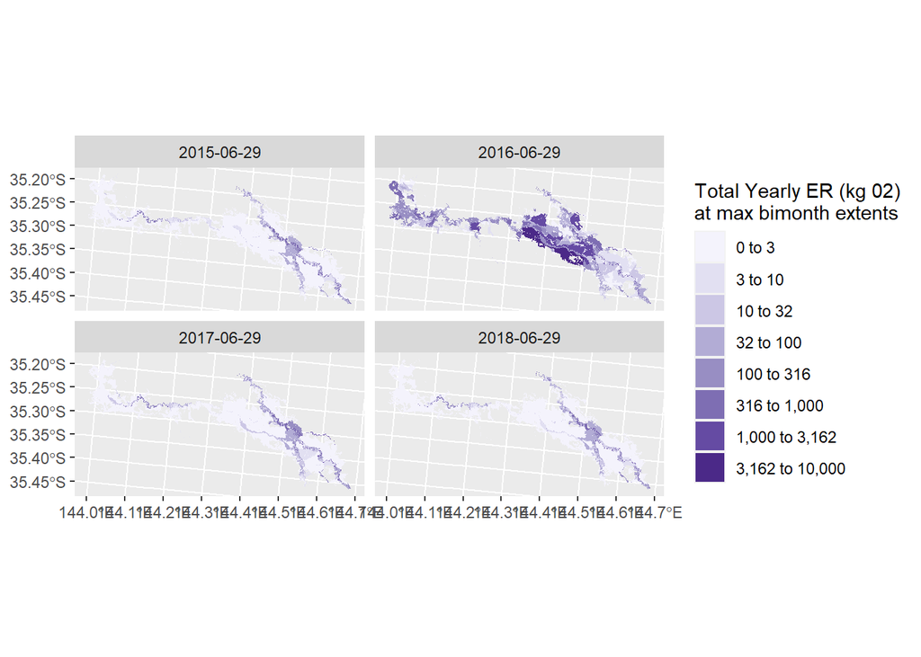

Stack 3 years of gpp and ER together for the document

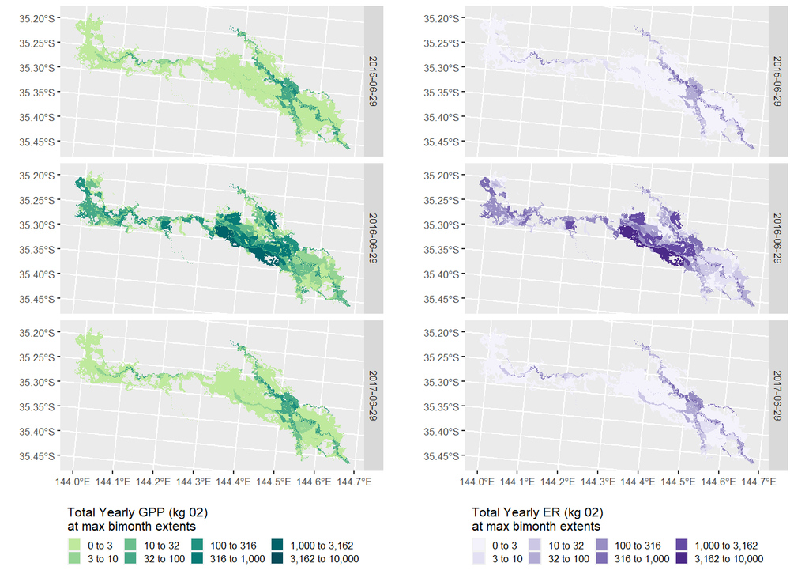

Print out the ggplots for the doc